# Assumption

## 회귀분석의 가정

회귀분석의 가정을 체크하는 데에는 R이 더 좋다. 일반적으로 Python 생태계는 회귀분석을 통계적으로 사용한다기보다, 머신러닝에 입문하기 위한 도구정도로 다뤄왔던 것 같다. 따라서 sklearn 같은 패키지에서 제공하는 방법은 다 7회차에 다룰 다중공선성의 해결과 관련있다. 회귀가정에 대한 예제를 찾는 것은 어렵고, 있더라도 불친절하고 불편하다. 회귀모델 피팅해주면 바로 잔차플롯 주는 R을 생각해보자…!

```r
library(data.table)
library(tidyverse)
```

```r
data = fread('2017-18_NBA_salary.csv')
```

```r
data %>% dim
```

```
## [1] 485  28
```

```r
data %>% glimpse
```

```
## Rows: 485
## Columns: 28
## $ Player          <chr> "Zhou Qi", "Zaza Pachulia", "Zach Randolph", "Zach ...
## $ Salary          <int> 815615, 3477600, 12307692, 3202217, 3057240, 131261...
## $ NBA_Country     <chr> "China", "Georgia", "USA", "USA", "USA", "USA", "US...
## $ NBA_DraftNumber <int> 43, 42, 19, 13, 10, 62, 62, 62, 23, 35, 62, 6, 40, ...
## $ Age             <int> 22, 33, 36, 22, 20, 24, 30, 23, 30, 23, 27, 24, 27,...
## $ Tm              <chr> "HOU", "GSW", "SAC", "CHI", "POR", "DAL", "BOS", "M...
## $ G               <int> 16, 66, 59, 24, 62, 79, 2, 5, 70, 45, 42, 70, 77, 6...
## $ MP              <int> 87, 937, 1508, 656, 979, 2238, 7, 118, 2200, 430, 4...
## $ PER             <dbl> 0.6, 16.8, 17.3, 14.6, 8.2, 11.5, -4.9, 0.9, 11.1, ...
## $ `TS%`           <dbl> 0.303, 0.608, 0.529, 0.499, 0.487, 0.543, 0.000, 0....
## $ `3PAr`          <dbl> 0.593, 0.004, 0.193, 0.346, 0.387, 0.489, 0.667, 0....
## $ FTr             <dbl> 0.370, 0.337, 0.140, 0.301, 0.146, 0.141, 0.000, 0....
## $ `ORB%`          <dbl> 6.5, 11.0, 7.0, 1.4, 4.9, 1.3, 15.9, 0.0, 5.0, 13.6...
## $ `DRB%`          <dbl> 16.8, 25.0, 23.8, 14.4, 18.3, 11.3, 15.4, 5.0, 14.0...
## $ `TRB%`          <dbl> 11.7, 18.5, 15.0, 7.7, 11.7, 6.1, 15.7, 2.5, 9.5, 1...
## $ `AST%`          <dbl> 1.5, 15.4, 14.9, 18.6, 7.3, 13.3, 0.0, 23.2, 9.7, 1...
## $ `STL%`          <dbl> 1.1, 1.9, 1.4, 1.8, 0.8, 1.4, 7.2, 2.6, 0.9, 1.8, 1...
## $ `BLK%`          <dbl> 6.8, 1.3, 0.6, 0.5, 2.5, 0.3, 0.0, 2.4, 1.4, 2.8, 4...
## $ `TOV%`          <dbl> 18.2, 19.3, 12.5, 9.7, 15.6, 9.1, 0.0, 19.3, 12.0, ...
## $ `USG%`          <dbl> 19.5, 17.2, 27.6, 29.5, 15.5, 17.0, 19.2, 21.7, 14....
## $ OWS             <dbl> -0.4, 1.7, 0.3, -0.1, -0.4, 1.6, -0.1, -0.5, 2.0, 0...
## $ DWS             <dbl> 0.1, 1.4, 1.1, 0.5, 1.2, 1.6, 0.0, 0.1, 1.0, 0.6, 0...
## $ WS              <dbl> -0.2, 3.1, 1.4, 0.4, 0.8, 3.1, 0.0, -0.4, 3.1, 1.4,...
## $ `WS/48`         <dbl> -0.121, 0.160, 0.046, 0.027, 0.038, 0.067, -0.251, ...
## $ OBPM            <dbl> -10.6, -0.6, -0.6, -0.7, -3.7, -0.4, -12.6, -8.7, -...
## $ DBPM            <dbl> 0.5, 1.3, -1.3, -2.0, 0.9, -0.5, -0.7, -1.9, -0.6, ...
## $ BPM             <dbl> -10.1, 0.8, -1.9, -2.6, -2.9, -0.9, -13.3, -10.6, -...
## $ VORP            <dbl> -0.2, 0.7, 0.0, -0.1, -0.2, 0.6, 0.0, -0.3, 0.5, 0....
```

```r
data %>% head()
```

```
##           Player   Salary NBA_Country NBA_DraftNumber Age  Tm  G   MP  PER
## 1:       Zhou Qi   815615       China              43  22 HOU 16   87  0.6
## 2: Zaza Pachulia  3477600     Georgia              42  33 GSW 66  937 16.8
## 3: Zach Randolph 12307692         USA              19  36 SAC 59 1508 17.3
## 4:   Zach LaVine  3202217         USA              13  22 CHI 24  656 14.6
## 5:  Zach Collins  3057240         USA              10  20 POR 62  979  8.2
## 6:  Yogi Ferrell  1312611         USA              62  24 DAL 79 2238 11.5
##      TS%  3PAr   FTr ORB% DRB% TRB% AST% STL% BLK% TOV% USG%  OWS DWS   WS
## 1: 0.303 0.593 0.370  6.5 16.8 11.7  1.5  1.1  6.8 18.2 19.5 -0.4 0.1 -0.2
## 2: 0.608 0.004 0.337 11.0 25.0 18.5 15.4  1.9  1.3 19.3 17.2  1.7 1.4  3.1
## 3: 0.529 0.193 0.140  7.0 23.8 15.0 14.9  1.4  0.6 12.5 27.6  0.3 1.1  1.4
## 4: 0.499 0.346 0.301  1.4 14.4  7.7 18.6  1.8  0.5  9.7 29.5 -0.1 0.5  0.4
## 5: 0.487 0.387 0.146  4.9 18.3 11.7  7.3  0.8  2.5 15.6 15.5 -0.4 1.2  0.8
## 6: 0.543 0.489 0.141  1.3 11.3  6.1 13.3  1.4  0.3  9.1 17.0  1.6 1.6  3.1
##     WS/48  OBPM DBPM   BPM VORP
## 1: -0.121 -10.6  0.5 -10.1 -0.2
## 2:  0.160  -0.6  1.3   0.8  0.7
## 3:  0.046  -0.6 -1.3  -1.9  0.0
## 4:  0.027  -0.7 -2.0  -2.6 -0.1
## 5:  0.038  -3.7  0.9  -2.9 -0.2
## 6:  0.067  -0.4 -0.5  -0.9  0.6
```

결측치는 일단 제거한다. 실제로 데이터 분석하면 왜 제거하는지 이유가 분명해야한다.

```r
data <- data[complete.cases(data), ] # 결측치 제거
data <- data[-c(223:224), ] #겹치는 선수 삭제
data$Player <- NULL # player 열 삭제
data$Tm <- NULL #팀의 효과는 관심없음, 팀의 순위도 아니고 그냥 팀...
data$NBA_Country <- NULL
data = data %>% select('Salary', 'NBA_DraftNumber', 'Age', 'MP', 'PER', `TS%`, `DRB%`, VORP, G, BPM)

# 그냥 일단 범주형 변수는 다 빼고 진행했습니다!
# 또한 제가 이전에 했던 결과상 적당히 변수 줄여서 진행했어요!
dim(data) # 최종 481행 10열
```

```
## [1] 481  10
```

#### 탐색적 자료분석

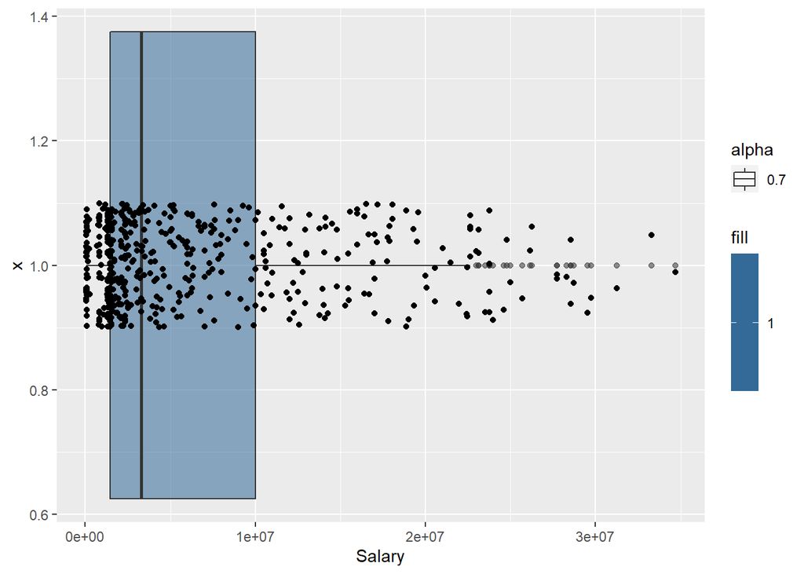

```r
library(ggplot2)
ggplot(data, aes(x = 1, y = Salary)) +
  geom_boxplot(aes(fill = 1, alpha = 0.7)) +
  coord_flip() +
  geom_jitter(width = 0.1)
```

y의 분포를 보았는데, 왼쪽으로 쏠려 있음을 확인 가능하고, 아마 정규성이 위배되어 있을 것이다. 하지만 일단 그냥 피팅해보자!

```r
salary.reg <- lm(Salary ~ ., data = data)
summary(salary.reg)
```

```
##
## Call:
## lm(formula = Salary ~ ., data = data)
##
## Residuals:
##       Min        1Q    Median        3Q       Max
## -14336974  -3163533   -365422   2180029  21370661
##
## Coefficients:
##                   Estimate Std. Error t value Pr(>|t|)
## (Intercept)     -7940731.3  2444594.5  -3.248  0.00124 **
## NBA_DraftNumber   -68241.1    12100.8  -5.639 2.95e-08 ***
## Age               529172.7    55122.9   9.600  < 2e-16 ***
## MP                  6127.8      771.8   7.939 1.50e-14 ***
## PER                26485.3    64759.2   0.409  0.68274
## `TS%`             484384.5  3521843.0   0.138  0.89066
## `DRB%`             92257.4    38151.4   2.418  0.01598 *
## VORP             1497866.2   289091.4   5.181 3.27e-07 ***
## G                -145830.0    23075.2  -6.320 6.08e-10 ***
## BPM               -25943.3   103291.9  -0.251  0.80180
## ---
## Signif. codes:  0 '***' 0.001 '**' 0.01 '*' 0.05 '.' 0.1 ' ' 1
##
## Residual standard error: 5097000 on 471 degrees of freedom
## Multiple R-squared:  0.5353, Adjusted R-squared:  0.5264
## F-statistic: 60.27 on 9 and 471 DF,  p-value: < 2.2e-16
```

적절하게 유의한 변수가 있는거 같기도 하면서 별로인 친구들도 보인다.

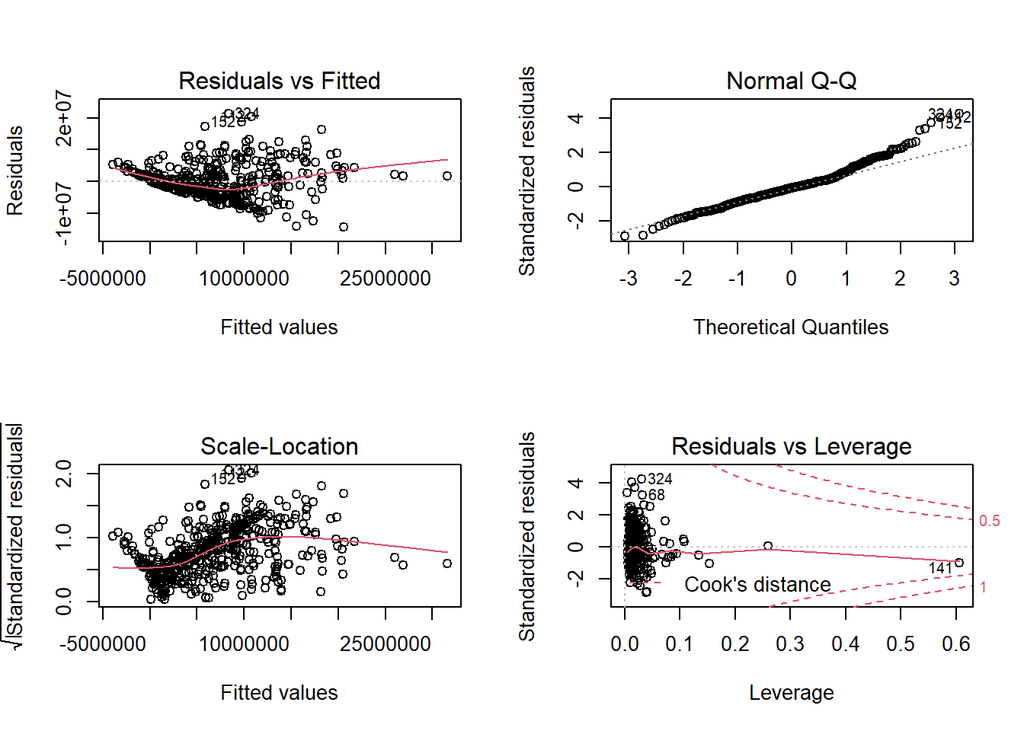

```r
par(mfrow = c(2,2))
plot(salary.reg) # 등분산, 정규성 등등 다 에바인데...?
```

```r
par(mfrow = c(1,1))
```

잔차플롯을 먼저 보면, 선형성도 살짝 위배된거 같고 megaphone shape로 등분산성도 위배된것 같다. 또한 qq 플랏상에서도 많이 벗어나보이므로 정규성도 위배되었다. 여러 테스트들을 확인해보자!

#### 테스트들 먼저 해볼까?

```r
library(car)
library(gvlma)
```

```r
gvlma_salary = gvlma(salary.reg )
gvlma_salary %>% summary
```

```
##
## Call:
## lm(formula = Salary ~ ., data = data)
##
## Residuals:
##       Min        1Q    Median        3Q       Max
## -14336974  -3163533   -365422   2180029  21370661
##
## Coefficients:
##                   Estimate Std. Error t value Pr(>|t|)
## (Intercept)     -7940731.3  2444594.5  -3.248  0.00124 **
## NBA_DraftNumber   -68241.1    12100.8  -5.639 2.95e-08 ***
## Age               529172.7    55122.9   9.600  < 2e-16 ***
## MP                  6127.8      771.8   7.939 1.50e-14 ***
## PER                26485.3    64759.2   0.409  0.68274
## `TS%`             484384.5  3521843.0   0.138  0.89066
## `DRB%`             92257.4    38151.4   2.418  0.01598 *
## VORP             1497866.2   289091.4   5.181 3.27e-07 ***
## G                -145830.0    23075.2  -6.320 6.08e-10 ***
## BPM               -25943.3   103291.9  -0.251  0.80180
## ---
## Signif. codes:  0 '***' 0.001 '**' 0.01 '*' 0.05 '.' 0.1 ' ' 1
##
## Residual standard error: 5097000 on 471 degrees of freedom
## Multiple R-squared:  0.5353, Adjusted R-squared:  0.5264
## F-statistic: 60.27 on 9 and 471 DF,  p-value: < 2.2e-16
##
##
## ASSESSMENT OF THE LINEAR MODEL ASSUMPTIONS
## USING THE GLOBAL TEST ON 4 DEGREES-OF-FREEDOM:
## Level of Significance =  0.05
##
## Call:
##  gvlma(x = salary.reg)
##
##                      Value   p-value                   Decision
## Global Stat        113.688 0.000e+00 Assumptions NOT satisfied!
## Skewness            37.022 1.168e-09 Assumptions NOT satisfied!
## Kurtosis            50.181 1.402e-12 Assumptions NOT satisfied!
## Link Function       25.760 3.867e-07 Assumptions NOT satisfied!
## Heteroscedasticity   0.725 3.945e-01    Assumptions acceptable.
```

전체적인 회귀, 정규성, 불만족. 등분산성은 만족하는데 plot상으로는 맘에 안듬

#### 정규성검정

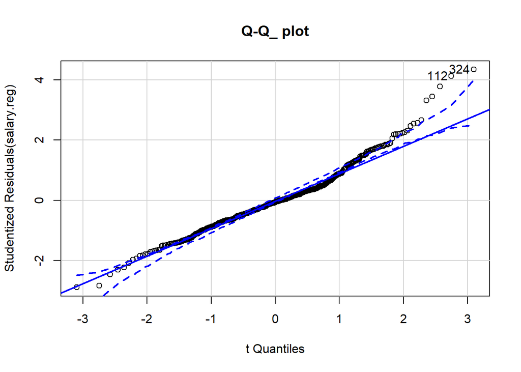

```
## [1] 112 324
```

```r
car::qqPlot(salary.reg,id.method="identify",simulate=TRUE,main="Q-Q_ plot")
```

이 함수를 사용할 경우, Confidence interval도 반환하기 때문에 좀더 시각적인 도움을 준다.

```r
shapiro.test(salary.reg$residuals)
```

```
##
##  Shapiro-Wilk normality test
##
## data:  salary.reg$residuals
## W = 0.96887, p-value = 1.41e-08
```

```r
tseries::jarque.bera.test(salary.reg$residuals)
```

```
##
##  Jarque Bera Test
##
## data:  salary.reg$residuals
## X-squared = 87.203, df = 2, p-value < 2.2e-16
```

```r
nortest::ad.test(salary.reg$residuals)
```

```
##
##  Anderson-Darling normality test
##
## data:  salary.reg$residuals
## A = 3.9766, p-value = 6.531e-10
```

세 테스트 다 귀무가설을 기각하므로, 정규성이 위배되었다.

#### 등분산성 검정

```r
lmtest::bptest(salary.reg)
```

```
##
##  studentized Breusch-Pagan test
##
## data:  salary.reg
## BP = 63.566, df = 9, p-value = 2.741e-10
```

```r
car::ncvTest(salary.reg)
```

```
## Non-constant Variance Score Test
## Variance formula: ~ fitted.values
## Chisquare = 90.52586, Df = 1, p = < 2.22e-16
```

등분산 가정 기각!

# 독립성검정

```r
lmtest::dwtest(salary.reg)
```

```
##
##  Durbin-Watson test
##
## data:  salary.reg
## DW = 1.8191, p-value = 0.02351
## alternative hypothesis: true autocorrelation is greater than 0
```

```r
car::durbinWatsonTest(salary.reg)
```

```
##  lag Autocorrelation D-W Statistic p-value
##    1      0.09000722      1.819091   0.048
##  Alternative hypothesis: rho != 0
```

왜 기각일까? 개별 관측치는 NBA 선수들. 따라서 같은 팀에 있거나 하는 경우 상관성이 나타날 수 있고하니… 하지만 엄청나게 심각한 위반이 일어나는것 같지 않으니, 나중에 다시 보자!

여기서 두 값이 다르게 나오는 이유는 car패키지는 붓스트랩으로 검정하기 때문이다.

### 정규성 처방

```r
car::powerTransform(data$Salary) %>% summary # 0.22제곱을 salary에 해주면 된다!
```

```
## bcPower Transformation to Normality
##             Est Power Rounded Pwr Wald Lwr Bnd Wald Upr Bnd
## data$Salary    0.2158        0.22        0.161       0.2706
##
## Likelihood ratio test that transformation parameter is equal to 0
##  (log transformation)
##                            LRT df       pval
## LR test, lambda = (0) 66.33663  1 3.3307e-16
##
## Likelihood ratio test that no transformation is needed
##                            LRT df       pval
## LR test, lambda = (1) 517.9342  1 < 2.22e-16
```

```r
data$Salary <- data$Salary^(0.22)
```

박스 콕스!

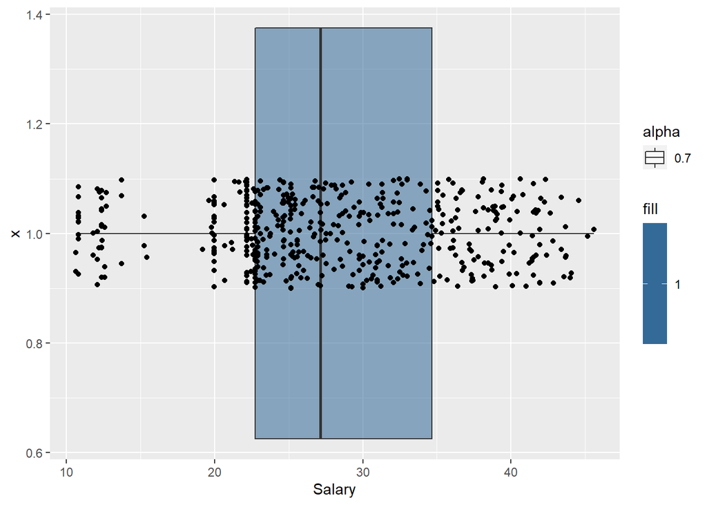

```r
ggplot(data, aes(x = 1, y = Salary)) +
  geom_boxplot(aes(fill = 1, alpha = 0.7)) +
  coord_flip() +
  geom_jitter(width = 0.1)
```

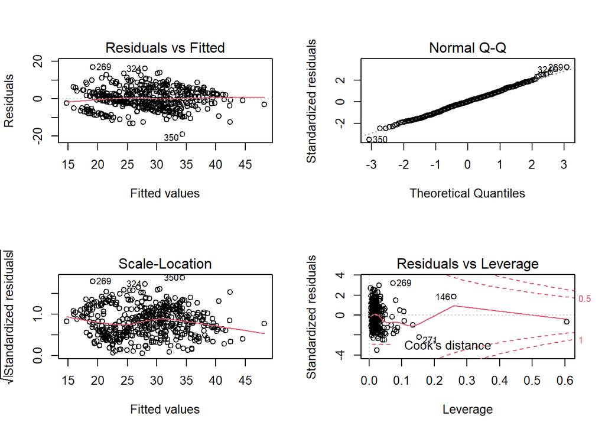

```r
salary.reg <- lm(Salary ~ ., data = data)
par(mfrow = c(2,2))
plot(salary.reg)
```

```r
par(mfrow = c(1,1))
```

정규성 이외에도 많이 나아진 것을 확인 가능!!

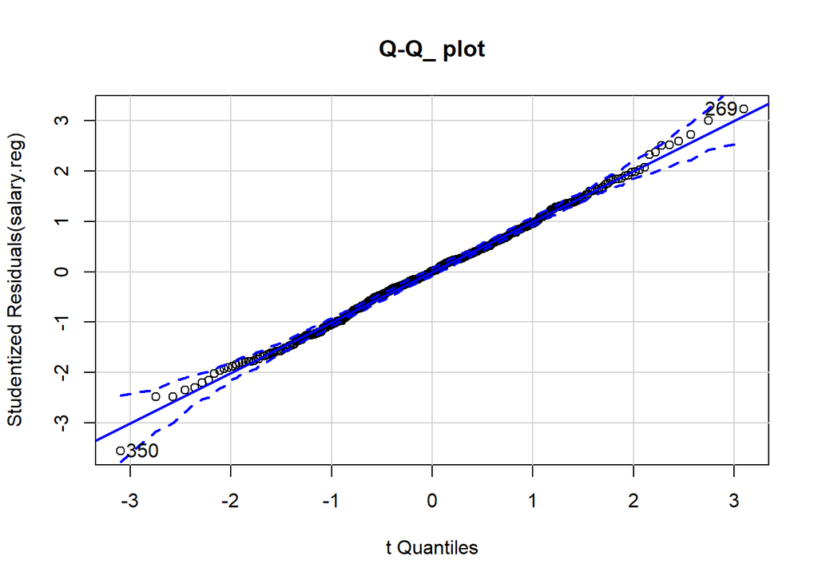

```
## [1] 269 350
```

```r
car::qqPlot(salary.reg,id.method="identify",simulate=TRUE,main="Q-Q_ plot")
```

이제 테스트로 확인해보자

```r
shapiro.test(salary.reg$residuals)
```

```
##
##  Shapiro-Wilk normality test
##
## data:  salary.reg$residuals
## W = 0.9976, p-value = 0.7245
```

```r
tseries::jarque.bera.test(salary.reg$residuals)
```

```
##
##  Jarque Bera Test
##
## data:  salary.reg$residuals
## X-squared = 0.28644, df = 2, p-value = 0.8666
```

```r
nortest::ad.test(salary.reg$residuals)
```

```
##
##  Anderson-Darling normality test
##
## data:  salary.reg$residuals
## A = 0.29525, p-value = 0.5951
```

**정규성 해결!!**

### 등분산성

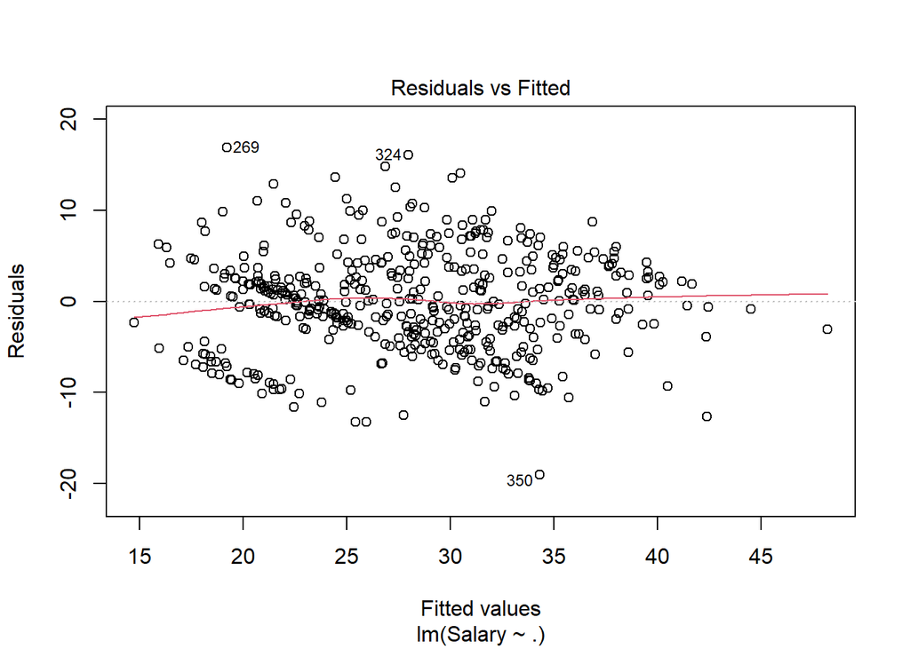

```r
plot(salary.reg, which = 1)
```

분산이 점점 감소하는거 같기도 한데, 그냥 관측치가 적어서 그런걸 수도! 테스트를 해보자!

```r
car::ncvTest(salary.reg)
```

```
## Non-constant Variance Score Test
## Variance formula: ~ fitted.values
## Chisquare = 0.6388379, Df = 1, p = 0.42413
```

**등분산 해결!!**

### 독립성

```r
car::durbinWatsonTest(salary.reg)
```

```
##  lag Autocorrelation D-W Statistic p-value
##    1        0.058693      1.882284   0.184
##  Alternative hypothesis: rho != 0
```

아까는 독립성이 깨졌었는데, 변환해주면서 더 우리의 모델이 설명을 잘해낸건지, 독립성도 괜찮다.

### 모델의 선형성

이제 오차 가정을 만족했으니, 선형성을 확인해 underfitting을 해결해보자

```r
salary.reg %>% summary  ## adj R^2  = 0.5512
```

```
##
## Call:
## lm(formula = Salary ~ ., data = data)
##
## Residuals:
##      Min       1Q   Median       3Q      Max
## -19.0588  -3.5812   0.0697   3.4690  16.8927
##
## Coefficients:
##                   Estimate Std. Error t value Pr(>|t|)
## (Intercept)      9.1707824  2.6341926   3.481 0.000545 ***
## NBA_DraftNumber -0.1169200  0.0130393  -8.967  < 2e-16 ***
## Age              0.6135173  0.0593982  10.329  < 2e-16 ***
## MP               0.0059306  0.0008317   7.131 3.78e-12 ***
## PER             -0.1163779  0.0697817  -1.668 0.096032 .
## `TS%`            4.8728971  3.7949905   1.284 0.199761
## `DRB%`           0.1469903  0.0411104   3.576 0.000386 ***
## VORP             0.4296699  0.3115128   1.379 0.168457
## G               -0.0781511  0.0248649  -3.143 0.001778 **
## BPM              0.1184993  0.1113030   1.065 0.287578
## ---
## Signif. codes:  0 '***' 0.001 '**' 0.01 '*' 0.05 '.' 0.1 ' ' 1
##
## Residual standard error: 5.492 on 471 degrees of freedom
## Multiple R-squared:  0.5597, Adjusted R-squared:  0.5512
## F-statistic: 66.51 on 9 and 471 DF,  p-value: < 2.2e-16
```

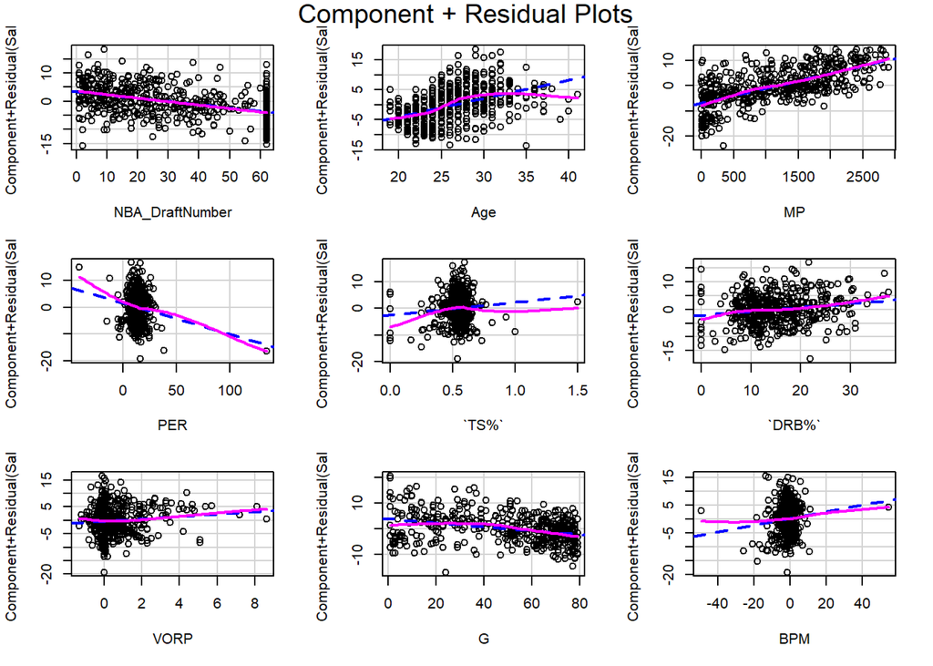

```r
crPlots(salary.reg)
```

선형성 같은 경우 Age와 G에 대한 이차항을 넣어주면 좋을것 같음!

```r
salary.reg2 <- lm(Salary ~ . + I(Age^2) + I(G^2), data = data)
summary(salary.reg2)  ### adj R^2 = 0.5893
```

```
##
## Call:
## lm(formula = Salary ~ . + I(Age^2) + I(G^2), data = data)
##
## Residuals:
##      Min       1Q   Median       3Q      Max
## -18.1302  -3.5155   0.1521   3.3853  17.0885
##
## Coefficients:
##                   Estimate Std. Error t value Pr(>|t|)
## (Intercept)     -3.347e+01  8.180e+00  -4.092 5.04e-05 ***
## NBA_DraftNumber -1.250e-01  1.307e-02  -9.568  < 2e-16 ***
## Age              3.570e+00  5.892e-01   6.058 2.82e-09 ***
## MP               6.290e-03  8.219e-04   7.653 1.13e-13 ***
## PER             -5.179e-02  6.807e-02  -0.761  0.44711
## `TS%`            3.522e+00  3.636e+00   0.969  0.33323
## `DRB%`           1.215e-01  3.976e-02   3.057  0.00237 **
## VORP             4.607e-01  3.015e-01   1.528  0.12724
## G                1.351e-01  5.077e-02   2.661  0.00805 **
## BPM             -1.034e-02  1.103e-01  -0.094  0.92537
## I(Age^2)        -5.344e-02  1.057e-02  -5.054 6.21e-07 ***
## I(G^2)          -2.566e-03  5.694e-04  -4.507 8.30e-06 ***
## ---
## Signif. codes:  0 '***' 0.001 '**' 0.01 '*' 0.05 '.' 0.1 ' ' 1
##
## Residual standard error: 5.254 on 469 degrees of freedom
## Multiple R-squared:  0.5987, Adjusted R-squared:  0.5893
## F-statistic:  63.6 on 11 and 469 DF,  p-value: < 2.2e-16
```

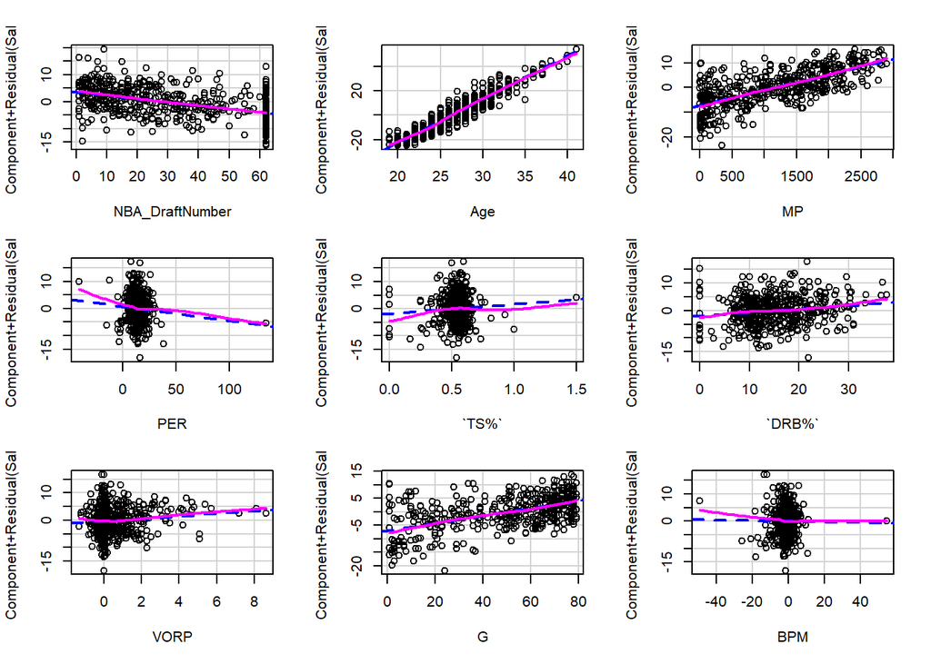

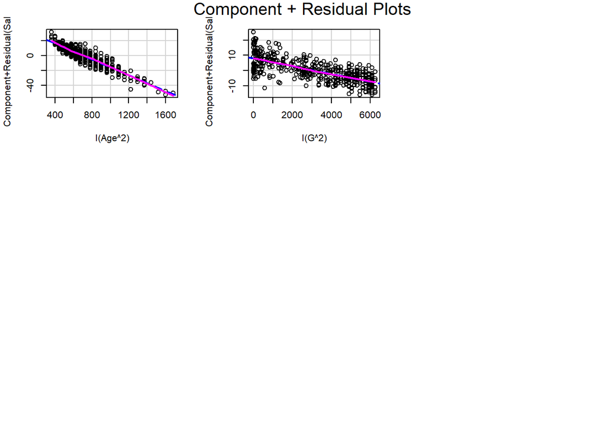

```r
crPlots(salary.reg2)
```

확실히 선형관계를 더 잘 잡아내고 있고, 그에따라 adj R^2값도 상승했다!!!

최종 잔차플롯을 그려볼까?

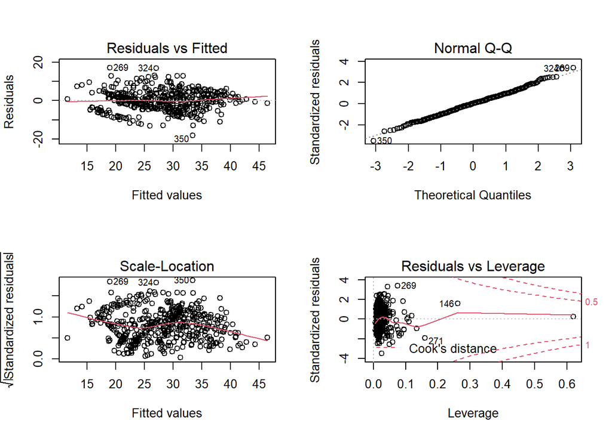

```r
par(mfrow = c(2,2))
plot(salary.reg2)
```

```r
par(mfrow = c(1,1))
```

scale location은 맘에 안들지만….나름 괜찮다!

```r
gvlma(salary.reg2)
```

```
##
## Call:
## lm(formula = Salary ~ . + I(Age^2) + I(G^2), data = data)
##
## Coefficients:
##     (Intercept)  NBA_DraftNumber              Age               MP
##      -33.474194        -0.125012         3.569624         0.006290
##             PER            `TS%`           `DRB%`             VORP
##       -0.051792         3.522153         0.121522         0.460652
##               G              BPM         I(Age^2)           I(G^2)
##        0.135129        -0.010339        -0.053444        -0.002566
##
##
## ASSESSMENT OF THE LINEAR MODEL ASSUMPTIONS
## USING THE GLOBAL TEST ON 4 DEGREES-OF-FREEDOM:
## Level of Significance =  0.05
##
## Call:
##  gvlma(x = salary.reg2)
##
##                      Value p-value                Decision
## Global Stat        3.12961  0.5364 Assumptions acceptable.
## Skewness           0.25720  0.6121 Assumptions acceptable.
## Kurtosis           1.52114  0.2174 Assumptions acceptable.
## Link Function      1.32852  0.2491 Assumptions acceptable.
## Heteroscedasticity 0.02275  0.8801 Assumptions acceptable.
```

전체 검정도 만족한다!!!